# CPgeneProfiler

Generate a profile of carbapenamase genes from the genome assemblies

## Author

[Prakki Sai Rama Sridatta](https://twitter.com/prakki_rama)

## DOI

[figure not shown]

## Synopsis

CPgene-profiler checks for a list of CarbaPenamase (CP) genes from a list of genome assemblies provided in fasta file format. It reports the profile of all the CP genes available in the genome assemblies in the format of simple heatmap. Apart from this, it also reports the presence of co-carriage of CP genes within an assembly. Other assembly statistics such as N50, N90, Assembly Size from the assembly are calculated and plots of length distribution of CP gene contigs from the list of assemblies are reported.

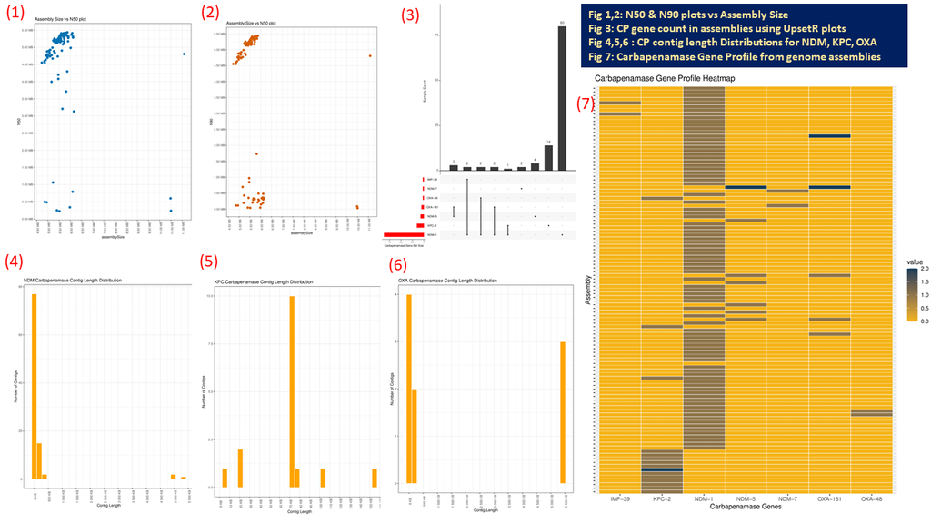

Example of graphics created using the CPgeneProfiler

## Quick Start

```
% CPgeneProfiler("/path/Folder_with_Fasta/")
```

# Installation

Install devtools first, and then need to load them:

```
install.packages(devtools)
library(devtools)
```

Then install the CPgeneProfiler package using devtools. While installing, switching off to upgrade dependencies

```
devtools::install_github("ramadatta/CPgeneProfiler",dependencies = FALSE)
```

## Source

```
https://github.com/ramadatta/CPgeneProfiler
```

# Check installation

Ensure you have installed the package properly:

```
?CPgeneProfiler
```

# Carbapenamase Gene Profiling

## Input Requirements

- a folder with multiple FASTA files (can be in multiple contigs)

## Output Files

- a folder “CPgene-profiler_Output” with the following files

| File | Description |
| --- | --- |
| assemblyStats.txt | A simple text file with N50, N90, Assembly Size for each assembly |
| blastResults.filt.txt | Filtered blast results with contains contigs matching CPgenes with 100% identity and 100% coverage |
| blastResults.txt | Blast Results of contigs against the CP genes |
| Co-carriage_Report.txt | Information of Number of assemblies with the co-carriage broken down to category |
| CPContigSizeDist.txt | Contig Size distribution |
| CPgeneProfile.tiff | Carbapenamase Gene Profile in .tiff format |
| CPgene-profiler.pdf | Plots of Assembly Stats, UpsetR Plots with co-carriage information in assemblies, Carbapenamase gene profile |
| cp_presence-abence_matrix.csv | Presence-absence matrix of CP genes across assemblies |
| N50_N90.pdf | N50, N90 vs Assembly Size plot |
| NDM_Contig_Dist.tiff | NDM gene contig length distribution |
| KPC_Contig_Dist.tiff | KPC gene contig length distribution |
| OXA_Contig_Dist.tiff | OXA gene contig length distribution |
| upSetR.pdf | intersection plot of samples based on Carbapenamase genes |
| DiffCP_DiffContig.txt | Information of assemblies with different CP genes present in different contigs |
| DiffCP_SameContig.txt | Information of assemblies with different CP genes present in same contigs |
| SameCP_DiffContig.txt | Information of assemblies with same CP genes present in different contigs |
| SameCP_SameContig.txt | Information of assemblies with same CP genes present in same contigs |

## Requirements (R-packages)

dplyr, tidyverse, UpSetR, scales, ape, Biostrings, reshape2, gridExtra

## Requirements (To be installed in Linux)

Command line NCBI blast+ (program assumes blastn and makeblastdb commands are in /usr/bin/)

## Version history

version 0.2.0

## References

Jake R Conway, Alexander Lex, Nils Gehlenborg, UpSetR: an R package for the visualization of intersecting sets and their properties, Bioinformatics, Volume 33, Issue 18, 15 September 2017, Pages 2938–2940, https://doi.org/10.1093/bioinformatics/btx364